# Project: Movies data analysis

# Movies Popularity Trend over Years?

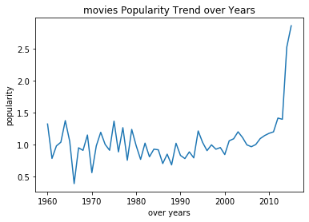

```python
over_year= df.groupby(['release_year']).mean()['popularity']
over_year.plot()
plt.xlabel("over years")
plt.ylabel("popularity")
plt.title("movies Popularity Trend over Years")
```

we can see Popularity over years is increse There are several reasons for this incrses importnat reason is Internet revolution.

# is runtime has related with poplurty ?

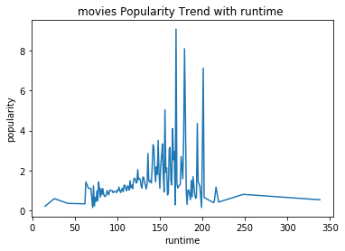

```python
overtime=df.groupby(['runtime']).mean()['popularity']
overtime.plot()
plt.xlabel("runtime")
plt.ylabel("popularity")
plt.title("movies Popularity Trend with runtime ")
```

we can see there a relationship between if the movie time between 150-200 will become more Popularity

# who is director more than to prduce movies and what is mean about reated

```python
df['director'].value_counts().head(1)
```

```
Steven Spielberg    27
Name: director, dtype: int64
```

```python
df.query('director == "Steven Spielberg"').mean()[['vote_average']]
```

```
vote_average    6.814815
dtype: float64
```

director who is Produce more than other directors is Steven Spielberg and mean of his reated movies is 6.81

```python
df.query('director == "Steven Spielberg"').head(3)
```

|  | id | popularity | budget | revenue | original_title | cast | director | keywords | runtime | genres | vote_count | vote_average | release_year |
| --- | --- | --- | --- | --- | --- | --- | --- | --- | --- | --- | --- | --- | --- |
| 33 | 296098 | 3.648210 | 40000000.0 | 162610473.0 | Bridge of Spies | Tom Hanks\|Mark Rylance\|Amy Ryan\|Alan Alda\|Seba... | Steven Spielberg | spy\|cia\|cold war\|pilot\|lawyer | 141 | Thriller\|Drama | 1638 | 7.1 | 2015 |
| 1334 | 840 | 1.104816 | 20000000.0 | 303788635.0 | Close Encounters of the Third Kind | Richard Dreyfuss\|FranÃ§ois Truffaut\|Teri Garr\|... | Steven Spielberg | indiana\|obsession\|extraterrestrial technology\|... | 135 | Science Fiction\|Drama | 600 | 7.0 | 1977 |
| 2638 | 644 | 2.971372 | 100000000.0 | 235926552.0 | A.I. Artificial Intelligence | Haley Joel Osment\|Frances O'Connor\|Sam Robards... | Steven Spielberg | ocean\|artificial intelligence\|prophecy\|android... | 146 | Drama\|Science Fiction\|Adventure | 1133 | 6.6 | 2001 |

# movies with longest time and movies with shortest time

```python
df.groupby(['runtime']).max().tail()
```

| runtime | id | popularity | budget | revenue | original_title | cast | director | keywords | genres | vote_count | vote_average | release_year |
| --- | --- | --- | --- | --- | --- | --- | --- | --- | --- | --- | --- | --- |
| 214 | 16072 | 0.469518 | 56000000.0 | 12923936.0 | Gods and Generals | Stephen Lang\|Jeff Daniels\|Robert Duvall\|Kevin ... | Ronald F. Maxwell | war\|battle\|union soldier\|confederate soldier\|a... | Drama\|History\|War | 23 | 5.8 | 2003 |
| 216 | 947 | 1.168767 | 15000000.0 | 70000000.0 | Lawrence of Arabia | Peter O'Toole\|Alec Guinness\|Anthony Quinn\|Jack... | David Lean | cairo\|arabian\|world war i\|horse\|jerusalem | Adventure\|Drama\|History\|War | 517 | 7.5 | 1962 |
| 219 | 10935 | 0.418950 | 44000000.0 | 3484331.0 | Heaven's Gate | Kris Kristofferson\|Christopher Walken\|John Hur... | Michael Cimino | montana\|showdown\|brothel\|marshal\|dance | Action\|Drama\|History\|Western | 18 | 6.0 | 1980 |
| 248 | 8095 | 0.804533 | 31115000.0 | 57750000.0 | Cleopatra | Elizabeth Taylor\|Richard Burton\|Rex Harrison\|R... | Joseph L. Mankiewicz\|Rouben Mamoulian\|Darryl F... | ancient rome\|historical figure\|cleopatra\|juliu... | Drama\|History\|Romance | 68 | 6.3 | 1963 |
| 338 | 43434 | 0.534192 | 18000000.0 | 871279.0 | Carlos | Edgar RamÃrez\|Alexander Scheer\|Fadi Abi Samra... | Olivier Assayas | gun\|car bomb\|tv mini-series\|terrorism\|opec | Crime\|Drama\|Thriller\|History | 35 | 6.2 | 2010 |

```python
df.groupby(['runtime']).min().head(5)
```

| runtime | id | popularity | budget | revenue | original_title | cast | director | keywords | genres | vote_count | vote_average | release_year |
| --- | --- | --- | --- | --- | --- | --- | --- | --- | --- | --- | --- | --- |
| 15 | 24914 | 0.208637 | 10.0 | 5.0 | Kid's Story | Clayton Watson\|Keanu Reeves\|Carrie-Anne Moss\|K... | Shinichiro Watanabe | no keywords | Science Fiction\|Animation | 16 | 6.8 | 2003 |
| 26 | 14813 | 0.592219 | 3000000.0 | 21000000.0 | Mickey's Christmas Carol | Alan Young\|Wayne Allwine\|Clarence Nash\|Hal Smi... | Burny Mattinson | cartoon\|scrooge\|ghost\|charles dickens\|christmas | Family\|Animation | 89 | 7.4 | 1983 |
| 42 | 14301 | 0.352054 | 200000.0 | 3.0 | Dr. Horrible's Sing-Along Blog | Neil Patrick Harris\|Nathan Fillion\|Felicia Day... | Joss Whedon | musical\|supervillain | Adventure\|Action\|Comedy\|Science Fiction\|Music | 140 | 7.7 | 2008 |
| 62 | 80379 | 0.331313 | 250000.0 | 1000000.0 | Louis C.K.: Live at the Beacon Theater | Louis C.K. | Louis C.K. | stand-up | Comedy | 47 | 7.9 | 2011 |
| 63 | 51162 | 1.425344 | 30000000.0 | 14460000.0 | Winnie the Pooh | Jim Cummings\|Travis Oates\|Jim Cummings\|Bud Luc... | Stephen Anderson\|Don Hall | owl\|tiger\|aftercreditsstinger\|duringcreditssti... | Animation\|Family | 174 | 6.8 | 2011 |